# AEEM 3062

# HOMEWORK # 10

# 2022-2023 SPRING

### Name: Slade Brooks

### M#: 13801712

### DUE: 11.59 PM on 4/13/2023

## Problem 1

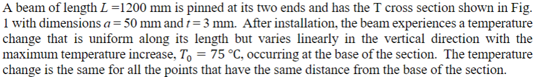

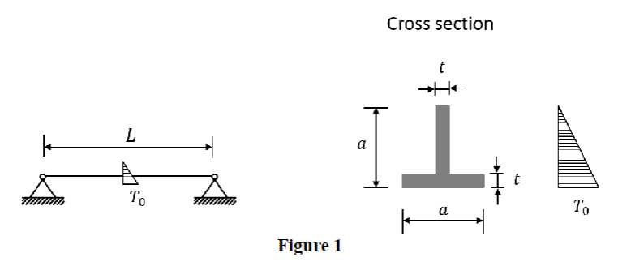

### Part A

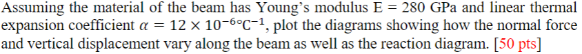

First we will find the centroid of the system by finding the centroid of each rectangle and then taking their weighted average. We know that the centroid will be at the exact horizontal midpoint of both rectangles since they share that axis of symmetry.

We will set the origin at the bottom and middle of the bar with y being the horizontal and z being the vertical axis.

The top rectangle has a center at $47/2$ so its centroid is at $(0, 47/2 + 3)$. The bottom rectangle has a center at $(0, 3/2)$.

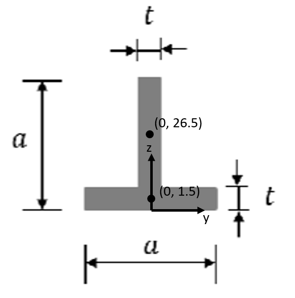

Then we take the weighted average: $$ z = \frac{26.5*3*47 + 1.5*3*50}{3*50+3*47} = 13.613 $$

Therefore the centroid is $(0, 13.613)$.

Now we will evaluate T at the centroid: $$ T(z) = -\frac{T_o}{a}z + T_o \\ T(13.613) = 54.58 $$

Now we can set up the differential equations:

$$ \frac{\partial N}{\partial x} = 0, \\ N = C_1 \\ \frac{\partial V}{\partial x} = 0, \\ V = C_3 \\ \frac{\partial M}{\partial x} = V = C_3, \\ M = C_3x + C_4L \\ \frac{\partial u}{\partial x} = \frac{N}{EA} + T_c\alpha = \frac{C_1}{EA} + T_c\alpha, \\ u = \frac{1}{EA}(C_1x + C_2L) + T_c\alpha x \\ \frac{\partial \varphi}{\partial x} = \frac{M}{EI}+\alpha\frac{T_o}{a} = \frac{C_3x + C_4L}{EI} + \frac{T_o}{a}\alpha, \\ \varphi = \frac{1}{EI}(\frac{C_3}{2}x^2 + C_4Lx + C_5L^2) + \frac{T_o}{a}\alpha x \\ \frac{\partial w}{\partial x} = \varphi = \frac{1}{EI}(\frac{C_3}{2}x^2 + C_4Lx + C_5L^2) + \frac{T_o}{a}\alpha x, \\ w = \frac{1}{EI}(\frac{C_3}{6}x^3 + \frac{C_4L}{2}x^2 + C_5L^2x + C_6L^3) + \frac{T_o}{2a}\alpha x^2 $$

And we can enforce boundary conditions at both ends: $$ u(0) = u(L) = 0 \\ w(0) = w(L) = 0 \\ M(0) = M(L) = 0 $$

And employ those to the equations:

$$ u(0) = 0 = \frac{1}{EA}(C_10 + C_2L) + T_c\alpha 0, \\ C_2 = 0 \\ w(0) = 0 = \frac{1}{EI}(\frac{C_3}{6}0^3 + \frac{C_4L}{2}0^2 + C_5L^20 + C_6L^3) + \frac{T_o}{2a}\alpha 0^2, \\ C_6 = 0 \\ M(0) = 0 = C_30 + C_4L,\\ C_4 = 0 \\ u(L) = 0 = \frac{1}{EA}(C_1L + 0L) + T_c\alpha L, \\ C_1 = -EAT_c\alpha \\ M(L) = 0 = C_3L + 0L, \\ C_3 = 0 \\ w(L) = 0 = \frac{1}{EI}(\frac{0}{6}L^3 + \frac{0L}{2}L^2 + C_5L^3 + 0L^3) + \frac{T_o}{2a}\alpha L^2, \\ C_5 = -\frac{EIT_o\alpha}{2aL} $$

Then we can convert units and solve for the constants.

$$ C_1 = -(280e9)(0.003*0.047 + 0.003*0.05)(54.58)(12e-6)\\ = -53366.14 \text{N} $$

Then plug back into equations:

$$ N(x) = -53366.14 \\ w(x) = -\frac{T_o\alpha L}{2a}x + \frac{T_o \alpha}{2a}x^2 $$

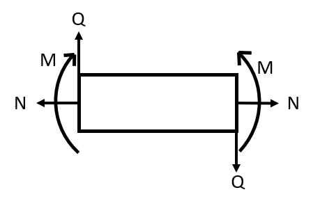

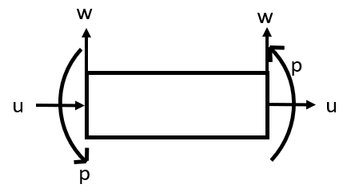

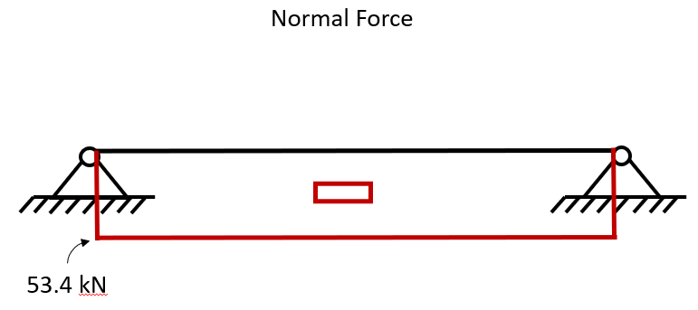

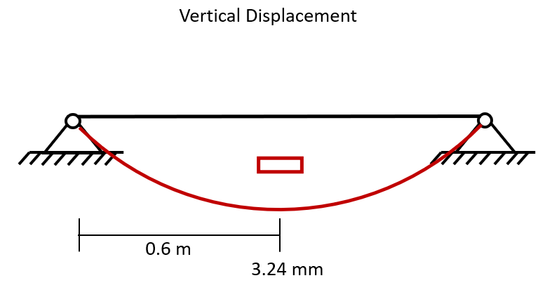

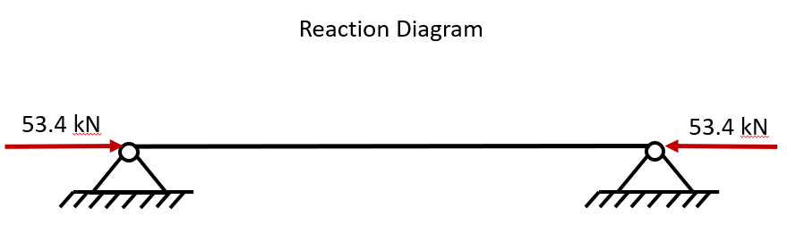

### Part B

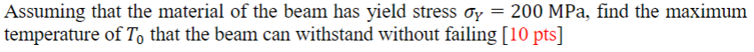

$$ \sigma_y = \frac{N}{A} = \frac{C_1}{A} = \frac{-EAT_c\alpha}{A} $$

$$ -E\alpha(-\frac{T_o}{a}z + T_o) = \sigma_y $$

$$ -\frac{T_o}{a}z+T_o=-\frac{\sigma_y}{E\alpha} $$

$$ T_o(-\frac{z}{a}+1) = -\frac{\sigma_y}{E\alpha} $$

$$ T_o = -\frac{\sigma_y}{E\alpha(-\frac{z}{a}+1)} $$

## Problem 2

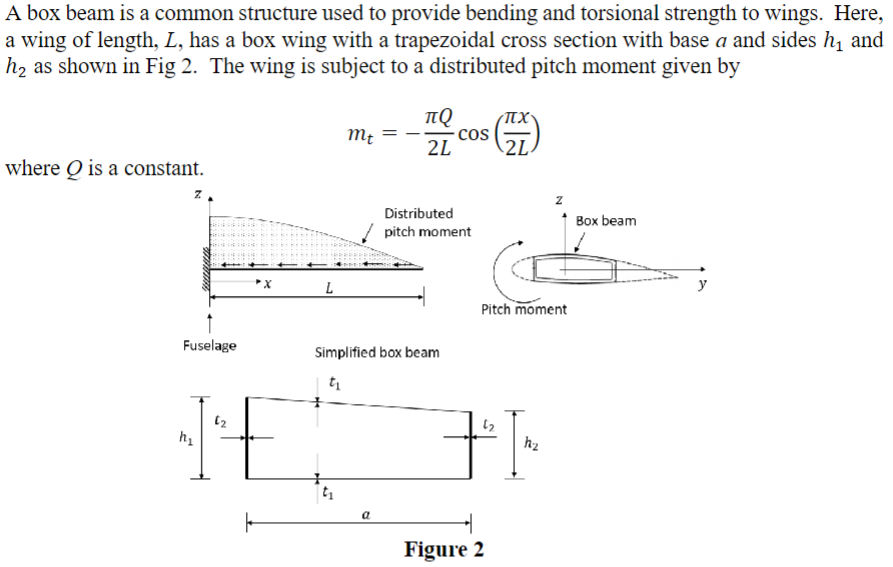

### Part A

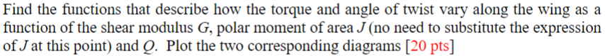

We will set up the differential equations:

$$ \frac{\partial M}{\partial x} = 0 - m_t = \frac{\pi Q}{2L}\cos{\frac{\pi x}{2L}}, M = \frac{\pi Q}{2L}\frac{\pi Q}{2L}\sin{\frac{\pi x}{2L}} + C_1, \\ M = Q\sin{\frac{\pi x}{2L}} + C_1 \\ \frac{\partial \theta}{\partial x} = \frac{m_t}{GJ}, \\ \theta = -\frac{1}{GJ}(\frac{2QL}{\pi}\cos{\frac{\pi x}{2L}} - C_1x) + C_2L $$

We can determine the boundary conditions: $$ m_t(L) = 0 \\ \theta(0) = 0 $$

And enforce them on the equations:

$$ m_t(L) = 0 = Q\sin{\frac{\pi L}{2L}} + C_1,\\ C_1 = -Q \\ \theta(0) = 0 = -\frac{1}{GJ}(\frac{2QL}{\pi}\cos{\frac{\pi 0}{2L}} - C_10) + C_2L, \\ C_2 = \frac{2Q}{GJ\pi} $$

And substitute back into the equations: $$ \fbox{$m_t(x) = Q(\sin{\frac{\pi x}{2L}} - 1)$} \\ \fbox{$\theta(x) = \frac{Q}{GJ}(-\frac{2L}{\pi}\cos{\frac{\pi x}{2L}}-x +\frac{2L}{\pi})$} $$

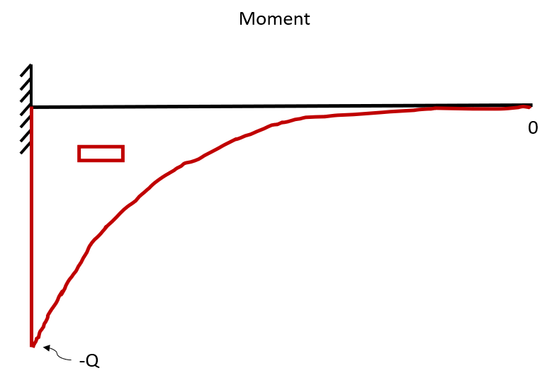

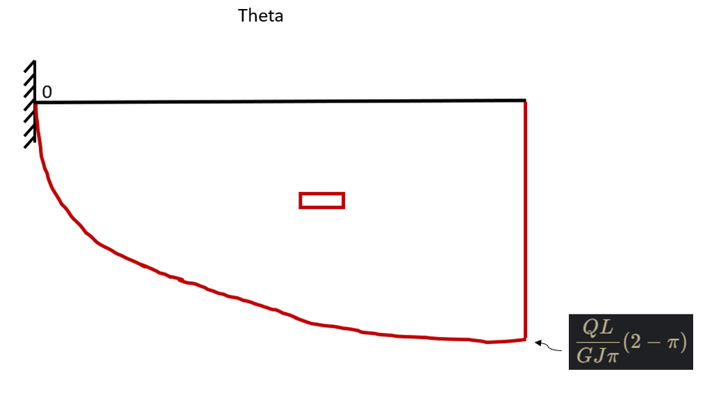

### Part B

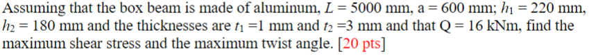

G of aluminum = 25.7e9 Pa (from slides)

$$ J = \frac{4\Sigma^2}{\int{\frac{1}{t(s)} ds}} $$

We neglect wall thickness so: $$ \Sigma = \frac{h_1+h_2}{2}a = 0.120 \text{m$^2$} $$

$$ \int{\frac{1}{t(s)}ds} = \int_0^a{\frac{1}{t_1}ds}+\int_0^{h_2}{\frac{1}{t_2}ds}+\int_0^{h_1}{\frac{1}{t_2}ds}+\int_0^{\sqrt{(h_1-h_2)^2+a^2}}{\frac{1}{t_1}ds}, \\ =\frac{a}{t_1}+\frac{h_2}{t_2}+\frac{h_1}{t_2}+\frac{\sqrt{(h_1-h_2)^2+a^2}}{t_1} = 1334.5 $$

$$ J = 4.316e-5 \text{m$^2$} $$

$$ q = \frac{m_t(x)}{2\Sigma} = \tau(s)t(s) $$

We will assume $\tau$ is constant.

$$ \tau(s) = \frac{m_t(x)}{2\Sigma t(s)} $$

Find location of max $m_t(x)$: $$ m_t(0) = -Q $$

Find location of min t(s): $$ t_1 = 0.001 $$

Therefore: $$ \fbox{$\tau(s)_{max} = -\frac{Q}{2\Sigma t_1} = -6.67e7 \text{Pa}$} $$

Max twist will be at: $$ \theta(L) = \frac{QL}{\pi GJ}(2-\pi) = -0.0262 \text{rad} = \fbox{$-1.5^\circ = \theta_{max}$} $$